# Contextual Word Embeddings

```r
library(dplyr)
library(tidytext)
library(wordVectors)
library(janeaustenr)
library(ggplot2)
library(Rtsne)
```

For an easy example I’ll use the Austen books corpus in the `janeaustenr` package.

```r
original <- austen_books() %>%
  group_by(book) %>%
  mutate(line = row_number()) %>%
  ungroup()

original
```

```
## # A tibble: 73,422 × 3
##                     text                book  line
##                    <chr>              <fctr> <int>
## 1  SENSE AND SENSIBILITY Sense & Sensibility     1
## 2                        Sense & Sensibility     2
## 3         by Jane Austen Sense & Sensibility     3
## 4                        Sense & Sensibility     4
## 5                 (1811) Sense & Sensibility     5
## 6                        Sense & Sensibility     6
## 7                        Sense & Sensibility     7
## 8                        Sense & Sensibility     8
## 9                        Sense & Sensibility     9
## 10             CHAPTER 1 Sense & Sensibility    10
## # ... with 73,412 more rows
```

# Preprocess

Now use tidytext magic to tokenize. Tidytext returns a tidy-format table, where each token is on its own row.

```r
tidy <- original %>%
  unnest_tokens(word, text)

tidy
```

```
## # A tibble: 725,054 × 3
##                   book  line        word
##                 <fctr> <int>       <chr>
## 1  Sense & Sensibility     1       sense
## 2  Sense & Sensibility     1         and
## 3  Sense & Sensibility     1 sensibility
## 4  Sense & Sensibility     3          by
## 5  Sense & Sensibility     3        jane
## 6  Sense & Sensibility     3      austen
## 7  Sense & Sensibility     5        1811
## 8  Sense & Sensibility    10     chapter
## 9  Sense & Sensibility    10           1
## 10 Sense & Sensibility    13         the
## # ... with 725,044 more rows
```

Now let’s make a tag for each book and prepend to a select set of words. For simplicity, let’s go ahead and use the factor level. We’ll use ‘#’ as an arbitrary delimiter that we’ll sacrifice later on because we aren’t interested at all in how Austen’s use of the pound sign changes between books.

```r
tidy <- tidy %>%
  mutate(word = ifelse(word == "time", paste0(as.numeric(book), '#', word),word))
```

And now prepare for word vectorizing by collapsing all words, adding a space between tokens first, into a single character object and then writing to a txt file.

```r
tidy %>%
  select(word) %>%
  unlist() %>%
  paste(collapse = " ") %>%
  writeChar("words.txt")
```

# Vectorize

Run word2vec, passing in the txt file we just made.

```r
vectors <- train_word2vec("words.txt")
```

We can check out the words most similar to “time” as used in Sense and Sensibility.

```r
nearest_to(vectors, vectors["1#time"])
```

```
##          1#time         rupture          edward        delaford
##    5.551115e-16    4.333790e-01    4.335112e-01    4.397578e-01
##       cleveland        whitwell         dawlish        marianne
##    4.471345e-01    4.558204e-01    4.666403e-01    4.683431e-01
## misapprehension      devonshire
##    4.811124e-01    4.819459e-01
```

compared with those most similar to “time” as used in Pride and Prejudice.

```r
nearest_to(vectors, vectors["2#time"])
```

```
##       2#time  netherfield      meryton        shire    longbourn
## 4.440892e-16 4.001277e-01 4.203427e-01 4.281954e-01 4.498352e-01
##     bingleys    pemberley       teased        lakes     officers
## 4.728810e-01 4.774213e-01 4.832315e-01 4.861970e-01 4.911538e-01
```

# Visualize

We can get fancy and use t-SNE to visualize how they relate.

```r
vec <- vectors@.Data
plottable_vectors <- Rtsne(vec, dims = 2, theta = 0.8, perplexity = 30, verbose = TRUE)
```

```
## Read the 5956 x 50 data matrix successfully!
## Using no_dims = 2, perplexity = 30.000000, and theta = 0.800000
## Computing input similarities...
## Normalizing input...
## Building tree...
##  - point 0 of 5956
## Done in 5.15 seconds (sparsity = 0.026686)!
## Learning embedding...
## Iteration 50: error is 87.425645 (50 iterations in 2.86 seconds)
## Iteration 100: error is 87.425661 (50 iterations in 2.60 seconds)
## Iteration 150: error is 87.425724 (50 iterations in 2.52 seconds)
## Iteration 200: error is 87.425777 (50 iterations in 2.67 seconds)
## Iteration 250: error is 87.425767 (50 iterations in 3.02 seconds)
## Iteration 300: error is 4.800527 (50 iterations in 2.91 seconds)
## Iteration 350: error is 3.764696 (50 iterations in 2.14 seconds)
## Iteration 400: error is 3.579926 (50 iterations in 1.86 seconds)
## Iteration 450: error is 3.512583 (50 iterations in 1.90 seconds)
## Iteration 500: error is 3.481526 (50 iterations in 1.84 seconds)
## Iteration 550: error is 3.465813 (50 iterations in 1.84 seconds)
## Iteration 600: error is 3.451484 (50 iterations in 1.86 seconds)
## Iteration 650: error is 3.443735 (50 iterations in 1.86 seconds)
## Iteration 700: error is 3.443898 (50 iterations in 1.88 seconds)
## Iteration 750: error is 3.446440 (50 iterations in 1.90 seconds)
## Iteration 800: error is 3.437868 (50 iterations in 1.90 seconds)
## Iteration 850: error is 3.442814 (50 iterations in 1.94 seconds)
## Iteration 900: error is 3.438002 (50 iterations in 1.92 seconds)
## Iteration 950: error is 3.433111 (50 iterations in 1.87 seconds)
## Iteration 1000: error is 3.433557 (50 iterations in 1.88 seconds)
## Fitting performed in 43.17 seconds.
```

Now we can plot on X&Y, coloring by book

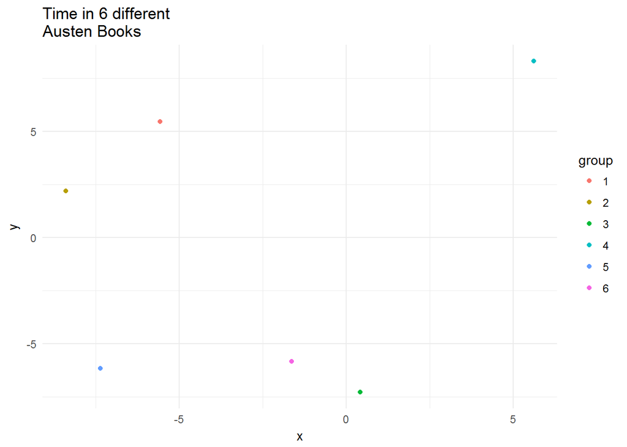

```r
plot_df <- data_frame(x = plottable_vectors$Y[,1],
                      y = plottable_vectors$Y[,2],
                      labels = row.names(vec))

sp <- stringr::str_split_fixed(plot_df$labels, "#", 2)
plot_df <- cbind(plot_df, sp)
colnames(plot_df)[4] <- 'group'
colnames(plot_df)[5] <- 'excess'
plot_df <- plot_df %>%
  mutate(group = ifelse(excess=="", "none",as.character(group)))

ggplot(subset(plot_df, group != "none"), aes(x,y, color=group)) +
  geom_point() +
  ggtitle("Time in 6 different \nAusten Books")+
  theme_minimal()
```

Success!